# Assignment 3: Model comparison

Marton Kovacs

In this lab assignment you are going to work with (simulated) data related to perioperative pain and its psychological and hormonal predictors. In the assignment you will assess the added benefit of including some psychological and hormonal predictors to the already established demographic predictors of pain.

In this assignment you will set up a hierarchical regression model to predict postoperative pain after wisdom tooth surgery.

# Research problem

The amount of pain experienced around and after surgeries are highly variable between and within individuals. In order to improve surgical pain management regimens we need to understand what influences pain around surgical procedures and predict the amount of pain an individual will experience.

Your first study in this area is related to assessing the influence of trait and state psychological measures on pain, and to see whether taking into account these variables can improve our understanding of postoperative pain.

# Procedures and measures

Use the data file called ‘assignment_3_dataset’, from the ‘data/’ folder.

You have collected data from 160 adults who were scheduled to undergo surgical extraction of the third mandibular molar (wisdom tooth surgery). Patients filled out a form in the waiting room before their surgery. The form contained questions about their sex, age, and weight, and psychological questionnaires assessing anxiety, pain catastrophizing, and mindfulness (see descriptions below). You also got blood samples and saliva samples from participants in the waiting room 5 minutes before their operations to determine the serum (a component of the blood) and salivary cortisol levels of participants. Participants were contacted 5 hours after the surgery to see how much pain they were experiencing. The **level of pain** at that moment was recorded using a numerical rating scale using a **scale of 0 to 10**, where 0 means “no pain” and 10 means “worst pain I can imagine”.

**The State Trait Anxiety Inventory:** T measures trait anxiety on a scale of 20 to 80, higher scores mean higher anxiety. Anxiety has been found in many studies to positively correlate with the level of pain experienced. This is **variable STAI_trait** in the dataset.

**The Pain Catastrophizing Scale** measures the extent of pain catastrophizing, which is characterized by a tendency to magnify the threat value of a pain stimulus and to feel helpless in the presence of pain, as well as by a relative inability to prevent or inhibit pain-related thoughts in anticipation of, during, or following a painful event. The total score on this scale ranges from 0 to 52, higher scores mean higher catastrophizing. Pain catastrophizing is one of the well-established predictors of clinical pain. This is **variable pain_cat** in the dataset.

**The Mindful Attention Awareness Scale (MAAS)** measures dispositional mindfulness, which may be described as a tendency to turn attention to present-moment experiences in an open, non-judgmental way. The MAAS total score ranges from 1 to 6 (an average of the item scores), with higher scores representing higher dispositional mindfulness. Trait mindfulness has been theorized to serve as a protective factor against pain, as the individual would be more objective about their pain experience and tend to associate less discomfort, despair, and hopelessness to the pain-related sensations. This is **variable mindfulness** in the dataset.

**Cortisol** is a stress hormone associated with acute and chronic stress. Cortisol levels are thought to be positively associated with pain experience. Cortisol can be **measured from both blood and the saliva**, although, serum cortisol is often regarded in medical research as more reliably related to stress (serum is a component of the blood plasma). These are **variables cortisol_serum**, and **cortisol_saliva** in the dataset.

# Research question

Previous studies and meta-analyses showed that age and sex are often predictors of pain (age is negatively associated with pain, while sex is a predictor more dependent on the type of the procedure). You would like to determine the extent to which taking into account psychological and hormonal variables aside from the already used demographic variables would improve our understanding of postoperative pain.

To answer this research question you will **need to compare two models** (with a hierarchical regression). The **simpler model** should contain **age and sex as predictors of pain**, while the **more complex model** should contain the **predictors: age, sex, STAI, pain catastrophizing, mindfulness, and cortisol measures**. Notice that the predictors used in the simpler model are a subset of the predictors used in more complex model. **You will have to do model comparison to assess whether substantial new information was gained about pain in the more complex model compared to the simpler model.**

# What to report

**Note:** If you do any changes, such as exclude cases, or exclude predictors from the model, you will have to re-run the above checks for your final data and model.

Report the results of the simpler model and the more complex model. For both models you should report the model test statistics (adj.R2, F, df, and p value). Also, report the statistics describing the coefficients of the predictors in a table format (unstandardized regression coefficients and 95% confidence intervals, standardized regression coefficients (B and Beta values), and p values).

Write up the regression equation of the more complex model in the form of 𝑌 = 𝑏0 + 𝑏1 ∗ X1 + 𝑏2 ∗ X2 +…+ bn * Xn, in which you use the actual regression coefficients of your models. (b0 stands for the intercept and b1, b2 … bn stand for the model coefficients for each of the predictors, and X1, X2, … Xn denote the predictors).

Compare the two models in terms of how much variance they explain of pain’s variability in the sample. Report Akaike information criterion (AIC) for both models and the F test statistic and p value of the likelihood ratio test comparing the two models.

# What to discuss

In your discussion of the findings, briefly interpret the results of the above analyses, and indicate whether you think that anything was gained by including the psychological and hormone measures in the model.

# Solution

## Read the data

Read the dataset used in this assignment. Pay attention to the extension of the datafile.

```r
library(tidyverse)
library(readxl)
library(funModeling)
library(Hmisc)
library(lm.beta)
library(car)
data_3 <- read_excel("~/assignment/public_r_data_analysis_2021_fall/data/assignment_3_dataset.xlsx")
## Data and model diagnostics
```

### Data diagnostics

#### Descriptives of the variables

Run an exploratory data analysis (EDA) to investigate the dataset.

```r
glimpse(data_3)
```

```
## Rows: 160
## Columns: 12
## $ ID               <chr> "ID_1", "ID_2", "ID_3", "ID_4", "ID_5", "ID_6", "I...
## $ pain             <dbl> 5, 4, 5, 7, 4, 6, 4, 5, 4, 5, 6, 3, 4, 5, 7, 4, 4,...
## $ sex              <chr> "female", "female", "female", "female", "male", "f...
## $ age              <dbl> 38, 36, 51, 39, 48, 45, 45, 35, 39, 33, 46, 42, 36...
## $ STAI_trait       <dbl> 39, 46, 49, 48, 36, 37, 34, 39, 31, 38, 37, 35, 37...
## $ pain_cat         <dbl> 25, 31, 32, 41, 26, 28, 22, 32, 27, 36, 26, 29, 26...
## $ cortisol_serum   <dbl> 4.67, 6.01, 5.18, 6.65, 2.95, 4.32, 5.32, 5.26, 3....
## $ cortisol_saliva  <dbl> 4.78, 6.71, 4.75, 6.68, 3.20, 4.36, 5.19, 5.53, 3....
## $ mindfulness      <dbl> 3.83, 2.82, 3.93, 1.90, 4.39, 3.01, 4.97, 2.95, 3....
## $ weight           <dbl> 62.14, 97.13, 78.96, 78.50, 76.88, 47.22, 55.10, 6...
## $ IQ               <dbl> 99, 71, 97, 97, 129, 115, 74, 98, 93, 76, 81, 103,...
## $ household_income <dbl> 52505, 64993, 68598, 47822, 100580, 43960, 65548, ...
```

```r
describe(data_3)
```

```
## data_3
##
##  12  Variables      160  Observations
## --------------------------------------------------------------------------------
## ID
##        n  missing distinct
##      160        0      160
##
## lowest : ID_1   ID_10  ID_100 ID_101 ID_102, highest: ID_95  ID_96  ID_97  ID_98  ID_99
## --------------------------------------------------------------------------------
## pain
##        n  missing distinct     Info     Mean      Gmd
##      160        0        9    0.962    5.194    2.248
##
## lowest :  1  2  3  4  5, highest:  5  6  7  8 50
##
## Value          1     2     3     4     5     6     7     8    50
## Frequency      3     7    20    28    43    31    25     2     1
## Proportion 0.019 0.044 0.125 0.175 0.269 0.194 0.156 0.013 0.006
## --------------------------------------------------------------------------------
## sex
##        n  missing distinct
##      160        0        3
##
## Value      female   male  woman
## Frequency      83     76      1
## Proportion  0.519  0.475  0.006
## --------------------------------------------------------------------------------
## age
##        n  missing distinct     Info     Mean      Gmd      .05      .10
##      160        0       24    0.996    40.74    5.682     32.0     34.0
##      .25      .50      .75      .90      .95
##     38.0     41.0     44.0     47.1     50.0
##
## lowest : 24 29 31 32 33, highest: 48 49 50 51 53
## --------------------------------------------------------------------------------
## STAI_trait
##        n  missing distinct     Info     Mean      Gmd      .05      .10
##      160        0       26    0.996    40.09    5.791     31.0     33.9
##      .25      .50      .75      .90      .95
```

[output cut: 45 more lines]

```
##        n  missing distinct     Info     Mean      Gmd      .05      .10
##      160        0       61    0.999    100.7    17.94    75.95    80.00
##      .25      .50      .75      .90      .95
##    91.75   101.00   109.00   121.00   129.05
##
## lowest :  52  60  68  70  71, highest: 136 137 139 143 144
## --------------------------------------------------------------------------------
## household_income
##        n  missing distinct     Info     Mean      Gmd      .05      .10
##      160        0      160        1    70426    27039    36126    41560
##      .25      .50      .75      .90      .95
##    53489    72149    87734   100410   109404
##
## lowest :   5548   8271  19620  21561  23662, highest: 115881 116610 121506 125500 139268
## --------------------------------------------------------------------------------
```

```r
freq(data_3)
```

```
##         ID frequency percentage cumulative_perc
## 1     ID_1         1       0.62            0.62
## 2    ID_10         1       0.62            1.24
## 3   ID_100         1       0.62            1.86
## 4   ID_101         1       0.62            2.48
## 5   ID_102         1       0.62            3.10
## 6   ID_103         1       0.62            3.72
## 7   ID_104         1       0.62            4.34
## 8   ID_105         1       0.62            4.96
## 9   ID_106         1       0.62            5.58
## 10  ID_107         1       0.62            6.20
## 11  ID_108         1       0.62            6.82
## 12  ID_109         1       0.62            7.44
## 13   ID_11         1       0.62            8.06
## 14  ID_110         1       0.62            8.68
```

[output cut: 146 more lines]

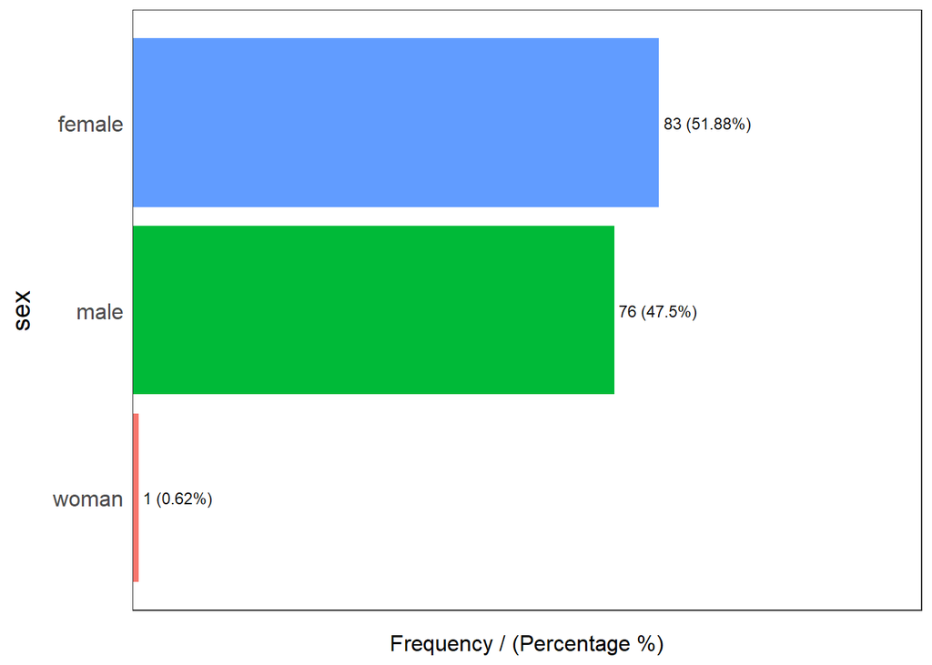

```
##      sex frequency percentage cumulative_perc
## 1 female        83      51.88           51.88
## 2   male        76      47.50           99.38
## 3  woman         1       0.62          100.00
```

```
## [1] "Variables processed: ID, sex"
```

```r
summary(data_3)
```

```
##       ID                 pain            sex                 age
##  Length:160         Min.   : 1.000   Length:160         Min.   :24.00
##  Class :character   1st Qu.: 4.000   Class :character   1st Qu.:38.00
##  Mode  :character   Median : 5.000   Mode  :character   Median :41.00
##                     Mean   : 5.194                      Mean   :40.74
##                     3rd Qu.: 6.000                      3rd Qu.:44.00
##                     Max.   :50.000                      Max.   :53.00
##    STAI_trait       pain_cat     cortisol_serum  cortisol_saliva
##  Min.   :26.00   Min.   :14.00   Min.   :2.700   Min.   :2.530
##  1st Qu.:37.00   1st Qu.:27.00   1st Qu.:4.268   1st Qu.:4.120
##  Median :40.00   Median :30.00   Median :4.995   Median :5.035
##  Mean   :40.09   Mean   :29.88   Mean   :4.941   Mean   :4.952
##  3rd Qu.:43.00   3rd Qu.:32.25   3rd Qu.:5.633   3rd Qu.:5.753
##  Max.   :52.00   Max.   :42.00   Max.   :7.110   Max.   :7.190
##   mindfulness        weight            IQ         household_income
##  Min.   :1.000   Min.   :33.80   Min.   : 52.00   Min.   :  5548
##  1st Qu.:2.595   1st Qu.:62.15   1st Qu.: 91.75   1st Qu.: 53489
##  Median :3.115   Median :68.77   Median :101.00   Median : 72149
##  Mean   :3.204   Mean   :68.57   Mean   :100.74   Mean   : 70426
##  3rd Qu.:3.830   3rd Qu.:74.65   3rd Qu.:109.00   3rd Qu.: 87734
##  Max.   :6.220   Max.   :97.13   Max.   :144.00   Max.   :139268
```

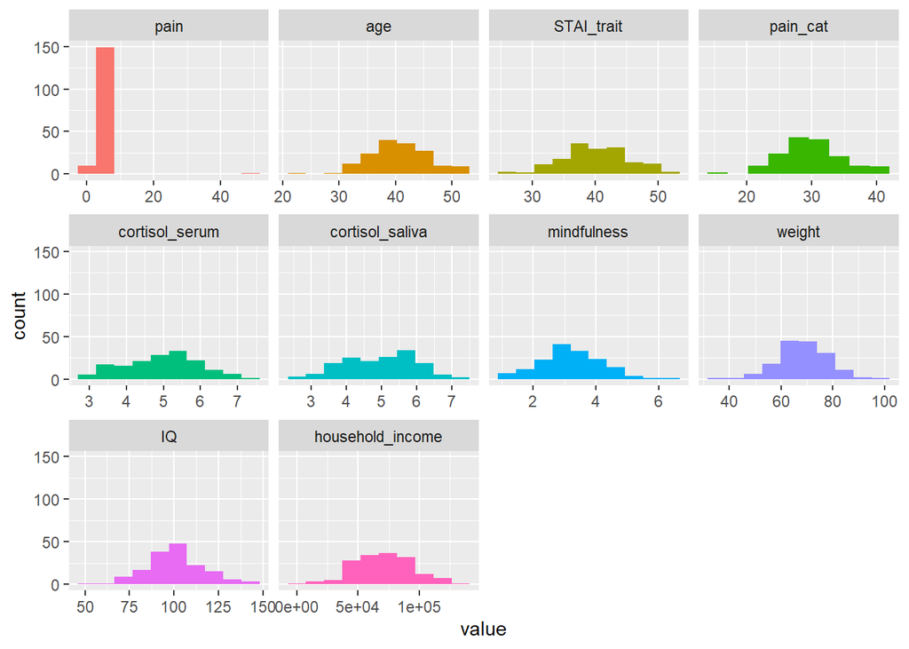

```r
plot_num(data_3)
```

#### Correct coding errors

I’ve found an extreme outlier in col. “pain”, which is out of the variable’s range (50). Value corrected, assuming it should have been 5. “Sex” variable has two names for female (“female”, “woman”). All “woman” values were changed to “female”.

```r
summary(data_3$pain)
```

```
##    Min. 1st Qu.  Median    Mean 3rd Qu.    Max.
##   1.000   4.000   5.000   5.194   6.000  50.000
```

```r
data_3[142, 2]=5

unique(data_3$sex)
```

```
## [1] "female" "male"   "woman"
```

```r
data_3 <- data_3 %>%
 mutate(sex = replace(sex, sex == "woman", "female"))
```

### Model diagnostics

#### Build the more complex model

```r
model_1 = lm(pain~age + sex + STAI_trait, data_3)
model_2=lm(pain~age + sex + STAI_trait +  mindfulness + IQ, data_3)

model_1 %>%
  summary()
```

```
##
## Call:
## lm(formula = pain ~ age + sex + STAI_trait, data = data_3)
##
## Residuals:
##     Min      1Q  Median      3Q     Max
## -4.4546 -0.8703  0.0954  0.8801  3.7333
##
## Coefficients:
##             Estimate Std. Error t value Pr(>|t|)
## (Intercept)  5.09663    1.19611   4.261 3.51e-05 ***
## age         -0.10344    0.02205  -4.691 5.91e-06 ***
## sexmale      0.37181    0.22833   1.628    0.105
## STAI_trait   0.09611    0.02240   4.291 3.11e-05 ***
## ---
## Signif. codes:  0 '***' 0.001 '**' 0.01 '*' 0.05 '.' 0.1 ' ' 1
##
## Residual standard error: 1.385 on 156 degrees of freedom
## Multiple R-squared:  0.1841, Adjusted R-squared:  0.1684
## F-statistic: 11.73 on 3 and 156 DF,  p-value: 5.665e-07
```

```r
model_1 %>%
lm.beta()
```

```
##
## Call:
## lm(formula = pain ~ age + sex + STAI_trait, data = data_3)
##
## Standardized Coefficients::
## (Intercept)         age     sexmale  STAI_trait
##   0.0000000  -0.3434791   0.1226336   0.3259284
```

```r
model_1 %>%
coef()
```

```
## (Intercept)         age     sexmale  STAI_trait
##  5.09662664 -0.10343512  0.37181170  0.09611467
```

```r
model_1 %>%
confint(level = 0.95)
```

```
##                   2.5 %      97.5 %
## (Intercept)  2.73396525  7.45928803
## age         -0.14699250 -0.05987775
## sexmale     -0.07920524  0.82282864
## STAI_trait   0.05186801  0.14036134
```

```r
model_2 %>%
  summary()
```

```
##
## Call:
## lm(formula = pain ~ age + sex + STAI_trait + mindfulness + IQ,
##     data = data_3)
##
## Residuals:
##     Min      1Q  Median      3Q     Max
## -3.7782 -0.9421  0.1239  0.8821  3.5414
##
## Coefficients:
##             Estimate Std. Error t value Pr(>|t|)
## (Intercept)  7.64150    1.56347   4.888 2.54e-06 ***
## age         -0.09997    0.02169  -4.610 8.40e-06 ***
## sexmale      0.37517    0.22524   1.666  0.09783 .
## STAI_trait   0.06336    0.02492   2.542  0.01201 *
## mindfulness -0.34303    0.12816  -2.677  0.00824 **
## IQ          -0.00273    0.00688  -0.397  0.69205
## ---
## Signif. codes:  0 '***' 0.001 '**' 0.01 '*' 0.05 '.' 0.1 ' ' 1
##
## Residual standard error: 1.359 on 154 degrees of freedom
## Multiple R-squared:  0.2241, Adjusted R-squared:  0.199
## F-statistic: 8.898 on 5 and 154 DF,  p-value: 1.924e-07
```

```r
model_2 %>%
lm.beta()
```

```
##
## Call:
## lm(formula = pain ~ age + sex + STAI_trait + mindfulness + IQ,
##     data = data_3)
##
## Standardized Coefficients::
## (Intercept)         age     sexmale  STAI_trait mindfulness          IQ
##  0.00000000 -0.33197219  0.12374048  0.21484575 -0.22067122 -0.02898096
```

```r
model_2 %>%
coef()
```

```
##  (Intercept)          age      sexmale   STAI_trait  mindfulness           IQ
##  7.641502825 -0.099969951  0.375167489  0.063356948 -0.343026339 -0.002730159
```

```r
model_2 %>%
confint(level = 0.95)
```

```
##                   2.5 %      97.5 %
## (Intercept)  4.55288818 10.73011747
## age         -0.14280971 -0.05713019
## sexmale     -0.06979921  0.82013419
## STAI_trait   0.01411754  0.11259636
## mindfulness -0.59620322 -0.08984946
## IQ          -0.01632153  0.01086121
```

```r
anova(model_1, model_2)
```

```
## Analysis of Variance Table
##
## Model 1: pain ~ age + sex + STAI_trait
## Model 2: pain ~ age + sex + STAI_trait + mindfulness + IQ
##   Res.Df    RSS Df Sum of Sq      F  Pr(>F)
## 1    156 299.26
## 2    154 284.56  2    14.693 3.9757 0.02072 *
## ---
## Signif. codes:  0 '***' 0.001 '**' 0.01 '*' 0.05 '.' 0.1 ' ' 1
```

#### Checking for influential outliers

Outliers were identified and removed from the dataset.

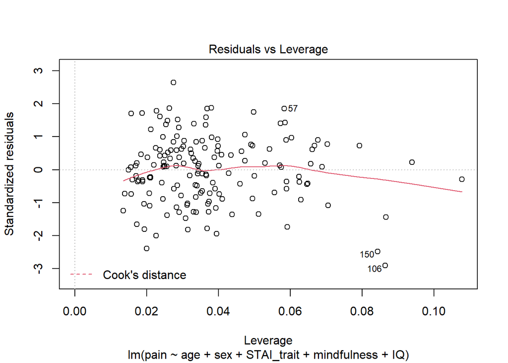

```r
model_2 %>%
  plot(5)
```

```r
data_3 <- data_3[-c(150, 106, 57, 81), ]
```

#### Checking assumptions

Plot shows normality assumption wasn’t violated.

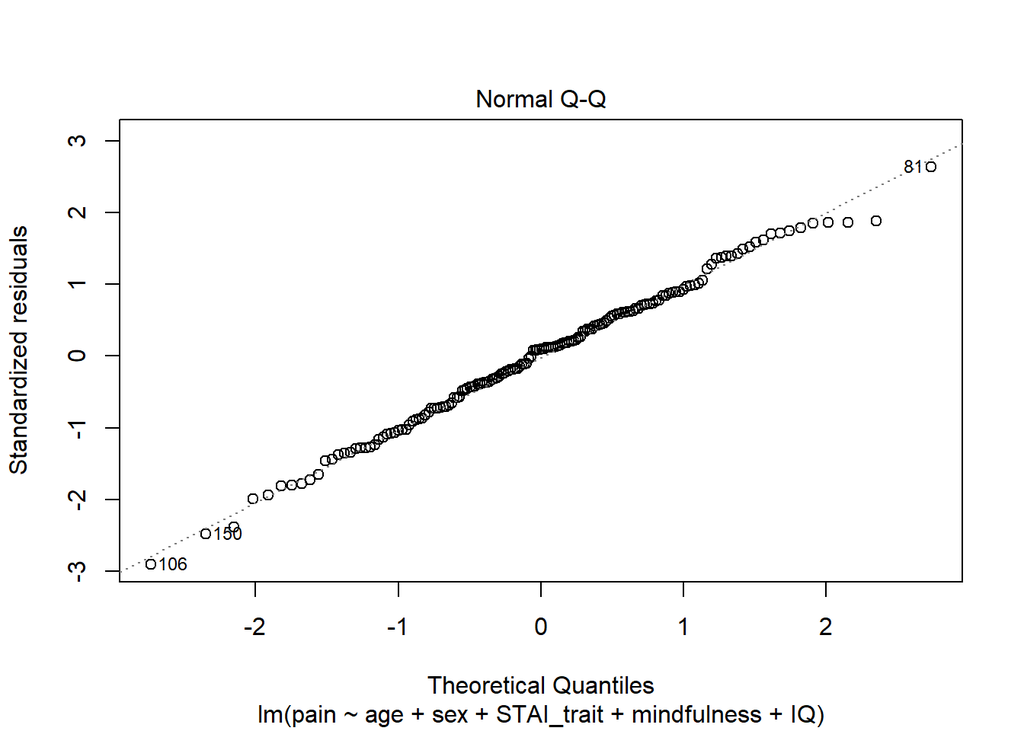

```r
model_2 %>%
  plot(2)
```

According to plot linearity assumption was met.

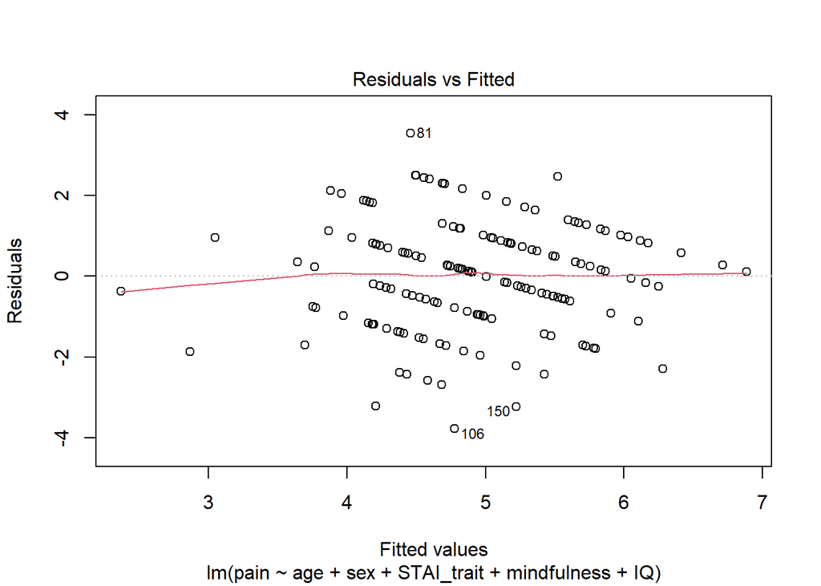

```r
model_2 %>%
  plot(1)
```

Homoscedasticty assumption was met.

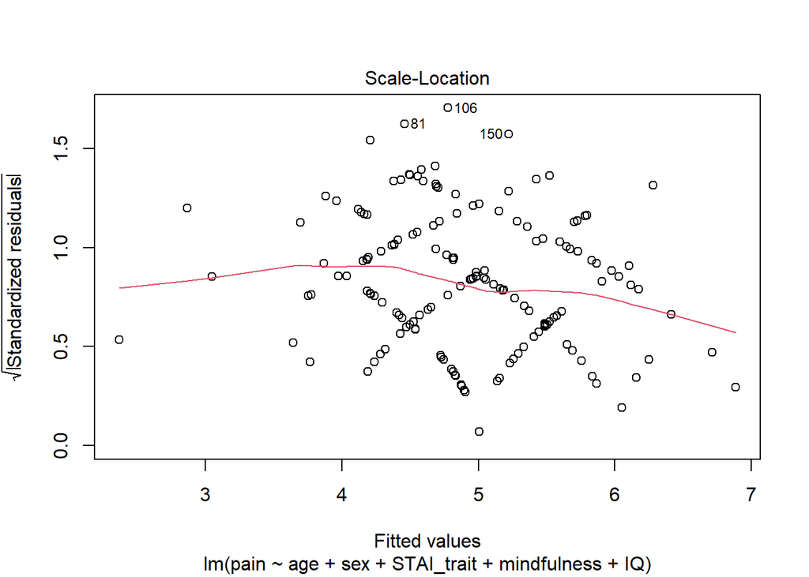

```r
model_2 %>%
  plot(3)
```

Testing multicollinearity, VIF was found to be under 5 (even 3) for all variables.

```r
model_2 %>%
vif()
```

```
##         age         sex  STAI_trait mindfulness          IQ
##    1.029315    1.095514    1.418014    1.349193    1.058683
```

### Making decision based on model diagnostics

“IQ” variable was dropped from the model, because it didn’t show a significant effect on the target variable.

```r
model_3 <- lm(pain~age + sex + STAI_trait +  mindfulness, data_3)
```

#### Checking outliers of the updated model

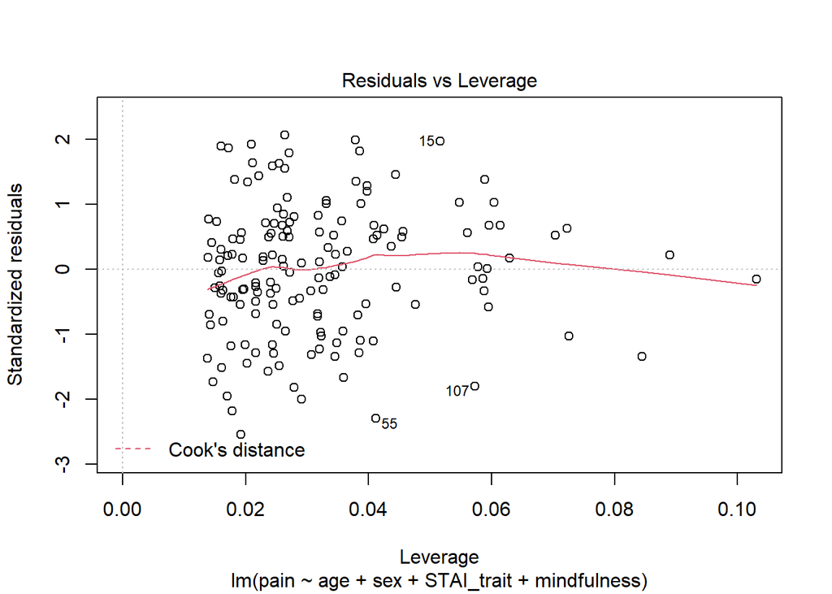

```r
model_3 %>%
  plot(5)
```

```r
data_3 <- data_3[-c(120, 55, 86, 107, 150),]
```

#### Checking assumptions of the updated model

Normality assumption was met.

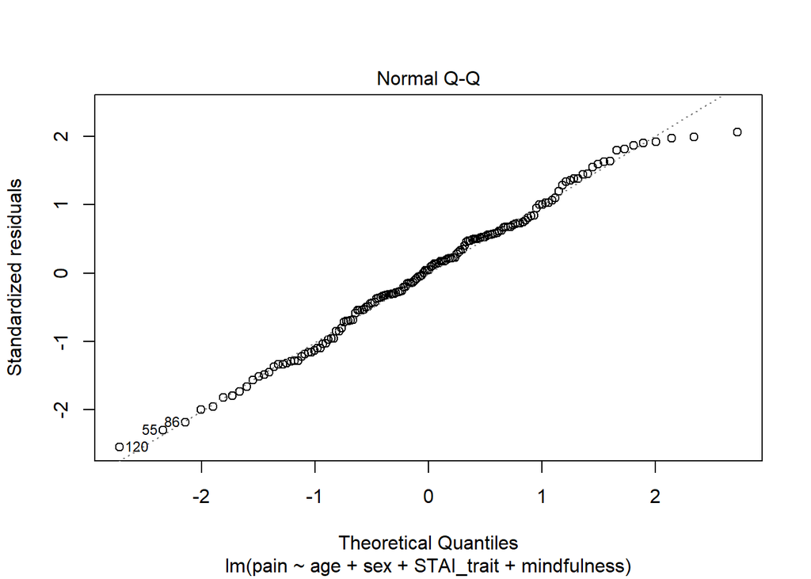

```r
model_3 %>%
  plot(2)
```

Linearity assumption was also met.

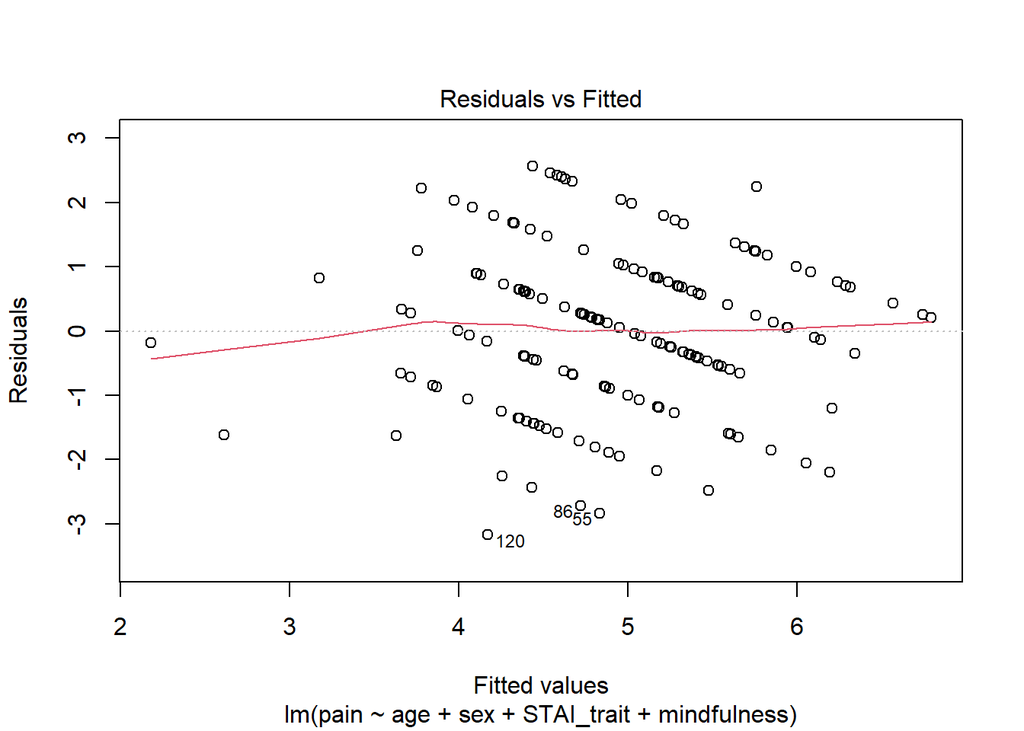

```r
model_3 %>%
  plot(1)
```

Homoscedasticty assumption was met.

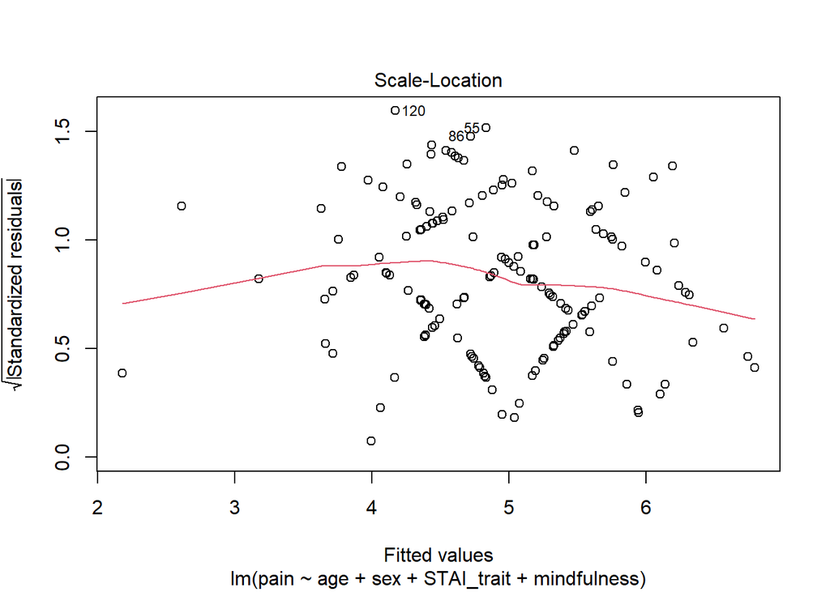

```r
model_3 %>%
  plot(3)
```

Multicollinearity assumption was met. VIF was under 5 (and 3) for all variables.

```r
model_3 %>%
vif()
```

```
##         age         sex  STAI_trait mindfulness
##    1.020990    1.088864    1.438766    1.329928
```

## Model comparison

```r
model_1 = lm(pain~age + sex + STAI_trait, data_3)

model_1 %>%
summary()
```

```
##
## Call:
## lm(formula = pain ~ age + sex + STAI_trait, data = data_3)
##
## Residuals:
##     Min      1Q  Median      3Q     Max
## -2.6853 -0.6989  0.1118  0.7723  2.7336
##
## Coefficients:
##             Estimate Std. Error t value Pr(>|t|)
## (Intercept)  3.85685    1.07304   3.594 0.000443 ***
## age         -0.09805    0.01932  -5.075 1.15e-06 ***
## sexmale      0.34983    0.20351   1.719 0.087722 .
## STAI_trait   0.12352    0.02001   6.174 6.18e-09 ***
## ---
## Signif. codes:  0 '***' 0.001 '**' 0.01 '*' 0.05 '.' 0.1 ' ' 1
##
## Residual standard error: 1.195 on 147 degrees of freedom
## Multiple R-squared:  0.2786, Adjusted R-squared:  0.2639
## F-statistic: 18.92 on 3 and 147 DF,  p-value: 1.964e-10
```

```r
model_3 <- lm(pain~age + sex + STAI_trait +  mindfulness, data_3)
model_3 %>%
summary()
```

```
##
## Call:
## lm(formula = pain ~ age + sex + STAI_trait + mindfulness, data = data_3)
##
## Residuals:
##      Min       1Q   Median       3Q      Max
## -2.55412 -0.72419  0.03154  0.73144  2.54077
##
## Coefficients:
##             Estimate Std. Error t value Pr(>|t|)
## (Intercept)  5.63803    1.31150   4.299 3.12e-05 ***
## age         -0.09609    0.01907  -5.040 1.36e-06 ***
## sexmale      0.36218    0.20069   1.805   0.0732 .
## STAI_trait   0.09790    0.02266   4.321 2.86e-05 ***
## mindfulness -0.26248    0.11426  -2.297   0.0230 *
## ---
## Signif. codes:  0 '***' 0.001 '**' 0.01 '*' 0.05 '.' 0.1 ' ' 1
##
## Residual standard error: 1.178 on 146 degrees of freedom
## Multiple R-squared:  0.3038, Adjusted R-squared:  0.2847
## F-statistic: 15.93 on 4 and 146 DF,  p-value: 7.685e-11
```

```r
model_3 %>%
lm.beta()
```

```
##
## Call:
## lm(formula = pain ~ age + sex + STAI_trait + mindfulness, data = data_3)
##
## Standardized Coefficients::
## (Intercept)         age     sexmale  STAI_trait mindfulness
##   0.0000000  -0.3514979   0.1303910   0.3607571  -0.1850379
```

```r
model_3 %>%
coef()
```

```
## (Intercept)         age     sexmale  STAI_trait mindfulness
##  5.63803163 -0.09609415  0.36218404  0.09789639 -0.26247959
```

```r
model_3 %>%
confint(level = 0.95)
```

```
##                   2.5 %      97.5 %
## (Intercept)  3.04606270  8.23000055
## age         -0.13377350 -0.05841481
## sexmale     -0.03444023  0.75880831
## STAI_trait   0.05311800  0.14267479
## mindfulness -0.48829013 -0.03666904
```

ANOVA shows that the two models differ significantly.

```r
anova(model_1, model_3)
```

```
## Analysis of Variance Table
##
## Model 1: pain ~ age + sex + STAI_trait
## Model 2: pain ~ age + sex + STAI_trait + mindfulness
##   Res.Df    RSS Df Sum of Sq      F  Pr(>F)
## 1    147 209.88
## 2    146 202.56  1     7.322 5.2775 0.02302 *
## ---
## Signif. codes:  0 '***' 0.001 '**' 0.01 '*' 0.05 '.' 0.1 ' ' 1
```